# 📦 **Online Retail Dataset Overview**

## 🔍 **About the Dataset**

### **Context**

In the world of e-commerce, datasets are often kept confidential, making it difficult to find high-quality, real-world data for analysis. However, the UCI Machine Learning Repository has provided a valuable exception. This dataset contains actual transaction records from a UK-based online retail company, spanning from December 1, 2010, to December 9, 2011. The dataset is publicly available under the title **"Online Retail."**

### **Dataset Content**

This dataset captures every transaction made within the specified period by a non-store online retailer in the UK. The company specializes in selling unique, all-occasion gifts, and many of its customers are wholesalers. The dataset includes:

- **InvoiceNo:** A unique identifier for each transaction.
- **StockCode:** A unique identifier for each product.
- **Description:** Product description.
- **Quantity:** The number of products purchased per transaction.
- **InvoiceDate:** The date of the transaction.
- **UnitPrice:** Price per product.
- **CustomerID:** A unique identifier for each customer.
- **Country:** The country where the customer resides.

### **Acknowledgements**

This dataset was generously provided by Dr. Daqing Chen, Director of the Public Analytics Group at the School of Engineering, London South Bank University. Dr. Chen's contributions have made it possible for researchers and data enthusiasts to explore real-world e-commerce data. For further inquiries, Dr. Chen can be contacted at chend '@' lsbu.ac.uk.

### **Inspiration for Analysis**

The "Online Retail" dataset offers a rich playground for a variety of data analysis techniques, including but not limited to:

- **Time Series Analysis:** Examine trends over time, such as peak shopping periods, seasonal effects, and sales cycles.
- **Clustering:** Identify distinct customer segments, such as frequent buyers, high spenders, or seasonal shoppers.
- **Classification:** Predict customer behavior, such as likelihood of repeat purchases or propensity to buy certain products.
- **Market Basket Analysis:** Discover relationships between products often purchased together.

This dataset provides an excellent opportunity to explore the dynamics of online retail and to gain insights into consumer behavior in the e-commerce space.

# 1. Import libraries

```python
import pandas as pd
import numpy as np
import matplotlib.pyplot as plt
import seaborn as sns
from datetime import datetime
```

```python
plt.style.use('ggplot')
```

# 2. Loading data

```python
df = pd.read_csv('data.csv', encoding = 'latin-1')
df.head()
```

|  | InvoiceNo | StockCode | Description | Quantity | InvoiceDate | UnitPrice | CustomerID | Country |
| --- | --- | --- | --- | --- | --- | --- | --- | --- |
| 0 | 536365 | 85123A | WHITE HANGING HEART T-LIGH... | 6 | 12/1/2010 8:26 | 2.55 | 17850.0 | United Kingdom |
| 1 | 536365 | 71053 | WHITE METAL LANTERN | 6 | 12/1/2010 8:26 | 3.39 | 17850.0 | United Kingdom |
| 2 | 536365 | 84406B | CREAM CUPID HEARTS COAT HA... | 8 | 12/1/2010 8:26 | 2.75 | 17850.0 | United Kingdom |
| 3 | 536365 | 84029G | KNITTED UNION FLAG HOT WAT... | 6 | 12/1/2010 8:26 | 3.39 | 17850.0 | United Kingdom |
| 4 | 536365 | 84029E | RED WOOLLY HOTTIE WHITE HE... | 6 | 12/1/2010 8:26 | 3.39 | 17850.0 | United Kingdom |

# 3. Initial Analysis

## 3.1. Initial Clean-up

```python
df.head()
```

|  | InvoiceNo | StockCode | Description | Quantity | InvoiceDate | UnitPrice | CustomerID | Country |
| --- | --- | --- | --- | --- | --- | --- | --- | --- |
| 0 | 536365 | 85123A | WHITE HANGING HEART T-LIGH... | 6 | 12/1/2010 8:26 | 2.55 | 17850.0 | United Kingdom |
| 1 | 536365 | 71053 | WHITE METAL LANTERN | 6 | 12/1/2010 8:26 | 3.39 | 17850.0 | United Kingdom |
| 2 | 536365 | 84406B | CREAM CUPID HEARTS COAT HA... | 8 | 12/1/2010 8:26 | 2.75 | 17850.0 | United Kingdom |
| 3 | 536365 | 84029G | KNITTED UNION FLAG HOT WAT... | 6 | 12/1/2010 8:26 | 3.39 | 17850.0 | United Kingdom |
| 4 | 536365 | 84029E | RED WOOLLY HOTTIE WHITE HE... | 6 | 12/1/2010 8:26 | 3.39 | 17850.0 | United Kingdom |

```python
df.info()
```

```
<class 'pandas.core.frame.DataFrame'>
RangeIndex: 541909 entries, 0 to 541908
Data columns (total 8 columns):
 #   Column       Non-Null Count   Dtype
---  ------       --------------   -----
 0   InvoiceNo    541909 non-null  object
 1   StockCode    541909 non-null  object
 2   Description  540455 non-null  object
 3   Quantity     541909 non-null  int64
 4   InvoiceDate  541909 non-null  object
 5   UnitPrice    541909 non-null  float64
 6   CustomerID   406829 non-null  float64
 7   Country      541909 non-null  object
dtypes: float64(2), int64(1), object(5)
memory usage: 33.1+ MB
```

```python
df['InvoiceDate'] = df['InvoiceDate'].astype('datetime64[ns]')
```

```python
df.isna().sum()
```

```
InvoiceNo           0
StockCode           0
Description      1454
Quantity            0
InvoiceDate         0
UnitPrice           0
CustomerID     135080
Country             0
dtype: int64
```

```python
df.dropna(subset=['CustomerID'], inplace=True)
```

```python
df.isnull().sum().sum()
```

```
0
```

```python
df['CustomerID'] = df['CustomerID'].astype(int).astype('object')
df.dtypes
```

```
InvoiceNo              object
StockCode              object
Description            object
Quantity                int64
InvoiceDate    datetime64[ns]
UnitPrice             float64
CustomerID             object
Country                object
dtype: object
```

```python
df.duplicated().sum()
```

```
5225
```

```python
df.drop_duplicates(inplace=True)
```

## 3.2. Summary Stats

```python
# df.describe(percentiles= np.arange(0, 1, 0.15)).T
df.describe().T
```

|  | count | mean | min | 25% | 50% | 75% | max | std |
| --- | --- | --- | --- | --- | --- | --- | --- | --- |
| Quantity | 401604.0 | 12.183273 | -80995.0 | 2.0 | 5.0 | 12.0 | 80995.0 | 250.283037 |
| InvoiceDate | 401604 | 2011-07-10 12:08:23.848567552 | 2010-12-01 08:26:00 | 2011-04-06 15:02:00 | 2011-07-29 15:40:00 | 2011-10-20 11:58:30 | 2011-12-09 12:50:00 | NaN |
| UnitPrice | 401604.0 | 3.474064 | 0.0 | 1.25 | 1.95 | 3.75 | 38970.0 | 69.764035 |

```python
df.describe(include='object').T
```

|  | count | unique | top | freq |
| --- | --- | --- | --- | --- |
| InvoiceNo | 401604 | 22190 | 576339 | 542 |
| StockCode | 401604 | 3684 | 85123A | 2065 |
| Description | 401604 | 3896 | WHITE HANGING HEART T-LIGH... | 2058 |
| CustomerID | 401604 | 4372 | 17841 | 7812 |
| Country | 401604 | 37 | United Kingdom | 356728 |

`Quantity:`

- std of Quantity is so high, then it should contain outliers
- contains negative values, it might be a order cancelation or return

## 3.3. Some columns' problems

### 3.3.1. Product Variety

```python
df.groupby(by = 'StockCode', as_index=False)['Quantity'].sum()
```

|  | StockCode | Quantity |
| --- | --- | --- |
| 0 | 10002 | 823 |
| 1 | 10080 | 291 |
| 2 | 10120 | 192 |
| 3 | 10123C | 5 |
| 4 | 10124A | 16 |
| ... | ... | ... |
| 3679 | D | -1194 |
| 3680 | DOT | 16 |
| 3681 | M | 2944 |
| 3682 | PADS | 4 |
| 3683 | POST | 3002 |

3684 rows × 2 columns

It seems like `StockCode` contains 5-6 characters, but there are some anamolies.

```python
df['StockCodeLen'] = df['StockCode'].apply(lambda x: len(x))
df['StockCodeDigitLen'] = df['StockCode'].apply(lambda x: sum(c.isdigit() for c in str(x)))
df.head()
```

|  | InvoiceNo | StockCode | Description | Quantity | InvoiceDate | UnitPrice | CustomerID | Country | StockCodeLen | StockCodeDigitLen |
| --- | --- | --- | --- | --- | --- | --- | --- | --- | --- | --- |
| 0 | 536365 | 85123A | WHITE HANGING HEART T-LIGH... | 6 | 2010-12-01 08:26:00 | 2.55 | 17850 | United Kingdom | 6 | 5 |
| 1 | 536365 | 71053 | WHITE METAL LANTERN | 6 | 2010-12-01 08:26:00 | 3.39 | 17850 | United Kingdom | 5 | 5 |
| 2 | 536365 | 84406B | CREAM CUPID HEARTS COAT HA... | 8 | 2010-12-01 08:26:00 | 2.75 | 17850 | United Kingdom | 6 | 5 |
| 3 | 536365 | 84029G | KNITTED UNION FLAG HOT WAT... | 6 | 2010-12-01 08:26:00 | 3.39 | 17850 | United Kingdom | 6 | 5 |
| 4 | 536365 | 84029E | RED WOOLLY HOTTIE WHITE HE... | 6 | 2010-12-01 08:26:00 | 3.39 | 17850 | United Kingdom | 6 | 5 |

```python
print("Value counts of numeric character frequencies in unique stock codes:")
print("-"*70)
print(df['StockCodeDigitLen'].value_counts())
```

```
Value counts of numeric character frequencies in unique stock codes:
----------------------------------------------------------------------
StockCodeDigitLen
5    399689
0      1781
1       134
Name: count, dtype: int64
```

```python
df[df['StockCodeDigitLen'] != 5].groupby(by = 'StockCode', as_index=False)['Quantity'].sum().sort_values(by= 'Quantity', ascending=False)
```

|  | StockCode | Quantity |
| --- | --- | --- |
| 7 | POST | 3002 |
| 5 | M | 2944 |
| 1 | C2 | 133 |
| 4 | DOT | 16 |
| 0 | BANK CHARGES | 12 |
| 6 | PADS | 4 |
| 2 | CRUK | -16 |
| 3 | D | -1194 |

```python
df[df['StockCodeDigitLen'] != 5][['StockCode','Description']].drop_duplicates()
```

|  | StockCode | Description |
| --- | --- | --- |
| 45 | POST | POSTAGE |
| 141 | D | Discount |
| 1423 | C2 | CARRIAGE |
| 2239 | M | Manual |
| 4406 | BANK CHARGES | Bank Charges |
| 157195 | PADS | PADS TO MATCH ALL CUSHIONS |
| 317507 | DOT | DOTCOM POSTAGE |
| 317508 | CRUK | CRUK Commission |

`StockCode` contains != 5 numerical characters are service-related products & add-on purchases and might be removed from the dataframe.

### 3.3.2. Unit Price

```python
df[df['UnitPrice'] == 0].head()
```

|  | InvoiceNo | StockCode | Description | Quantity | InvoiceDate | UnitPrice | CustomerID | Country | StockCodeLen | StockCodeDigitLen |
| --- | --- | --- | --- | --- | --- | --- | --- | --- | --- | --- |
| 9302 | 537197 | 22841 | ROUND CAKE TIN VINTAGE GREEN | 1 | 2010-12-05 14:02:00 | 0.0 | 12647 | Germany | 5 | 5 |
| 33576 | 539263 | 22580 | ADVENT CALENDAR GINGHAM SACK | 4 | 2010-12-16 14:36:00 | 0.0 | 16560 | United Kingdom | 5 | 5 |
| 40089 | 539722 | 22423 | REGENCY CAKESTAND 3 TIER | 10 | 2010-12-21 13:45:00 | 0.0 | 14911 | EIRE | 5 | 5 |
| 47068 | 540372 | 22090 | PAPER BUNTING RETROSPOT | 24 | 2011-01-06 16:41:00 | 0.0 | 13081 | United Kingdom | 5 | 5 |
| 47070 | 540372 | 22553 | PLASTERS IN TIN SKULLS | 24 | 2011-01-06 16:41:00 | 0.0 | 13081 | United Kingdom | 5 | 5 |

`UnitPrice` contains 0, it should be removed

### 3.3.3. InvoiceNo

```python
df[df['Quantity'] < 0 ]['InvoiceNo'].unique()
```

```
array(['C536379', 'C536383', 'C536391', ..., 'C581499', 'C581568',
       'C581569'], dtype=object)
```

`InvoiceNo` starts with "C" is the cancelled invoice.

```python
df['Invoice_Status'] = 'normal'
df.loc[df['InvoiceNo'].str.startswith('C'), 'Invoice_Status'] = 'cancel'
```

### 3.3.3. Resolve the problems

```python
df = df[df['StockCodeDigitLen'] == 5]
# df = df[df['UnitPrice'] > 0]
```

## 3.4. Feature Engineering

### 3.4.1. RFM features

#### Recency (R)

```python
df['InvoiceDate'] = pd.to_datetime(df['InvoiceDate'])
df['InvoiceDay'] = df['InvoiceDate'].dt.date
customer_data = df.groupby('CustomerID')['InvoiceDay'].max().reset_index()
most_recent_date = df['InvoiceDay'].max()
customer_data['InvoiceDay'] = pd.to_datetime(customer_data['InvoiceDay'])
most_recent_date = pd.to_datetime(most_recent_date)
customer_data['Days_Since_Last_Purchase'] = (most_recent_date - customer_data['InvoiceDay']).dt.days
customer_data.drop(columns=['InvoiceDay'], inplace=True)

customer_data.head()
```

|  | CustomerID | Days_Since_Last_Purchase |
| --- | --- | --- |
| 0 | 12346 | 325 |
| 1 | 12347 | 2 |
| 2 | 12348 | 75 |
| 3 | 12349 | 18 |
| 4 | 12350 | 310 |

#### Frequency (F)

```python
total_transactions = df.groupby('CustomerID')['InvoiceNo'].nunique().reset_index()
total_transactions.rename(columns={'InvoiceNo': 'Total_Transactions'}, inplace=True)

total_products_purchased = df.groupby('CustomerID')['Quantity'].sum().reset_index()
total_products_purchased.rename(columns={'Quantity': 'Total_Products_Purchased'}, inplace=True)

customer_data = pd.merge(customer_data, total_transactions, on='CustomerID')
customer_data = pd.merge(customer_data, total_products_purchased, on='CustomerID')

customer_data.head()
```

|  | CustomerID | Days_Since_Last_Purchase | Total_Transactions | Total_Products_Purchased |
| --- | --- | --- | --- | --- |
| 0 | 12346 | 325 | 2 | 0 |
| 1 | 12347 | 2 | 7 | 2458 |
| 2 | 12348 | 75 | 4 | 2332 |
| 3 | 12349 | 18 | 1 | 630 |
| 4 | 12350 | 310 | 1 | 196 |

#### Monetary (M)

```python
df['Total_Spend'] = df['UnitPrice'] * df['Quantity']
total_spend = df.groupby('CustomerID')['Total_Spend'].sum().reset_index()

average_transaction_value = total_spend.merge(total_transactions, on='CustomerID')
average_transaction_value['Average_Transaction_Value'] = average_transaction_value['Total_Spend'] / average_transaction_value['Total_Transactions']

customer_data = pd.merge(customer_data, total_spend, on='CustomerID')
customer_data = pd.merge(customer_data, average_transaction_value[['CustomerID', 'Average_Transaction_Value']], on='CustomerID')

customer_data.head()
```

|  | CustomerID | Days_Since_Last_Purchase | Total_Transactions | Total_Products_Purchased | Total_Spend | Average_Transaction_Value |
| --- | --- | --- | --- | --- | --- | --- |
| 0 | 12346 | 325 | 2 | 0 | 0.00 | 0.000000 |
| 1 | 12347 | 2 | 7 | 2458 | 4310.00 | 615.714286 |
| 2 | 12348 | 75 | 4 | 2332 | 1437.24 | 359.310000 |
| 3 | 12349 | 18 | 1 | 630 | 1457.55 | 1457.550000 |
| 4 | 12350 | 310 | 1 | 196 | 294.40 | 294.400000 |

### 3.4.2. Behaviour features

```python
# Extract day of week and hour from InvoiceDate
df['Day_Of_Week'] = df['InvoiceDate'].dt.dayofweek
df['Hour'] = df['InvoiceDate'].dt.hour
```

```python
# Calculate the average number of days between consecutive purchases
days_between_purchases = df.groupby('CustomerID')['InvoiceDay'].apply(lambda x: (x.diff().dropna()).apply(lambda y: y.days))
average_days_between_purchases = days_between_purchases.groupby('CustomerID').mean().reset_index()
average_days_between_purchases.rename(columns={'InvoiceDay': 'Average_Days_Between_Purchases'}, inplace=True)
```

```python
# Find the favorite shopping day of the week
favorite_shopping_day = df.groupby(['CustomerID', 'Day_Of_Week']).size().reset_index(name='Count')
favorite_shopping_day = favorite_shopping_day.loc[favorite_shopping_day.groupby('CustomerID')['Count'].idxmax()][['CustomerID', 'Day_Of_Week']]
```

```python
# Find the favorite shopping hour of the day
favorite_shopping_hour = df.groupby(['CustomerID', 'Hour']).size().reset_index(name='Count')
favorite_shopping_hour = favorite_shopping_hour.loc[favorite_shopping_hour.groupby('CustomerID')['Count'].idxmax()][['CustomerID', 'Hour']]
```

```python
# Merge the new features into the customer_data dataframe
customer_data = pd.merge(customer_data, average_days_between_purchases, on='CustomerID')
customer_data = pd.merge(customer_data, favorite_shopping_day, on='CustomerID')
customer_data = pd.merge(customer_data, favorite_shopping_hour, on='CustomerID')
```

```python
# Display the first few rows of the customer_data dataframe
customer_data.head()
```

|  | CustomerID | Days_Since_Last_Purchase | Total_Transactions | Total_Products_Purchased | Total_Spend | Average_Transaction_Value | Average_Days_Between_Purchases | Day_Of_Week | Hour |
| --- | --- | --- | --- | --- | --- | --- | --- | --- | --- |
| 0 | 12346 | 325 | 2 | 0 | 0.00 | 0.000000 | 0.000000 | 1 | 10 |
| 1 | 12347 | 2 | 7 | 2458 | 4310.00 | 615.714286 | 2.016575 | 1 | 14 |
| 2 | 12348 | 75 | 4 | 2332 | 1437.24 | 359.310000 | 10.884615 | 3 | 19 |
| 3 | 12349 | 18 | 1 | 630 | 1457.55 | 1457.550000 | 0.000000 | 0 | 9 |
| 4 | 12350 | 310 | 1 | 196 | 294.40 | 294.400000 | 0.000000 | 2 | 16 |

### 3.4.3. Product diversity

```python
# Calculate the number of unique products purchased by each customer
unique_products_purchased = df.groupby('CustomerID')['StockCode'].nunique().reset_index()
unique_products_purchased.rename(columns={'StockCode': 'Unique_Products_Purchased'}, inplace=True)
```

```python
customer_data = pd.merge(customer_data, unique_products_purchased, on='CustomerID')

customer_data.head()
```

|  | CustomerID | Days_Since_Last_Purchase | Total_Transactions | Total_Products_Purchased | Total_Spend | Average_Transaction_Value | Average_Days_Between_Purchases | Day_Of_Week | Hour | Unique_Products_Purchased |
| --- | --- | --- | --- | --- | --- | --- | --- | --- | --- | --- |
| 0 | 12346 | 325 | 2 | 0 | 0.00 | 0.000000 | 0.000000 | 1 | 10 | 1 |
| 1 | 12347 | 2 | 7 | 2458 | 4310.00 | 615.714286 | 2.016575 | 1 | 14 | 103 |
| 2 | 12348 | 75 | 4 | 2332 | 1437.24 | 359.310000 | 10.884615 | 3 | 19 | 21 |
| 3 | 12349 | 18 | 1 | 630 | 1457.55 | 1457.550000 | 0.000000 | 0 | 9 | 72 |
| 4 | 12350 | 310 | 1 | 196 | 294.40 | 294.400000 | 0.000000 | 2 | 16 | 16 |

### 3.4.4. Geographical features

```python
df['Country'].value_counts()
```

```
Country
United Kingdom          356110
Germany                   9081
France                    8152
EIRE                      7370
Spain                     2463
Netherlands               2330
Belgium                   1971
Switzerland               1844
Portugal                  1427
Australia                 1256
Norway                    1060
Italy                      783
Channel Islands            752
Finland                    653
Cyprus                     608
Sweden                     436
Austria                    387
Denmark                    375
Japan                      355
Poland                     336
USA                        291
Israel                     247
Unspecified                241
Singapore                  215
Iceland                    182
Canada                     150
Greece                     142
Malta                      123
United Arab Emirates        67
European Community          58
RSA                         57
Lebanon                     45
Lithuania                   35
Brazil                      32
Czech Republic              28
Bahrain                     17
Saudi Arabia                10
Name: count, dtype: int64
```

Most of orders are from UK, so it would be better to separate UK customers from others.

```python
df.groupby(by = 'CustomerID', as_index = False)['Country'].nunique().sort_values(by = 'Country', ascending = False)
```

|  | CustomerID | Country |
| --- | --- | --- |
| 56 | 12417 | 2 |
| 20 | 12370 | 2 |
| 38 | 12394 | 2 |
| 90 | 12455 | 2 |
| 69 | 12431 | 2 |
| ... | ... | ... |
| 1465 | 14332 | 1 |
| 1466 | 14333 | 1 |
| 1467 | 14334 | 1 |
| 1468 | 14335 | 1 |
| 4362 | 18287 | 1 |

4363 rows × 2 columns

So, it probably that some Customer purchased in more than 1 country.

```python
customer_main_country = df.groupby(by = ['CustomerID','Country'], as_index = False)\
    .agg(count_order = ('InvoiceNo', 'nunique'))\
        .sort_values(by = 'count_order', ascending = False)\
        .drop_duplicates(subset = 'CustomerID', keep = 'first')

customer_main_country['Is_UK'] = 0
customer_main_country.loc[customer_main_country['Country'] == 'United Kingdom', 'Is_UK'] = 1
customer_main_country.drop(columns = 'count_order', inplace = True)
customer_main_country
```

|  | CustomerID | Country | Is_UK |
| --- | --- | --- | --- |
| 1900 | 14911 | EIRE | 0 |
| 336 | 12748 | United Kingdom | 1 |
| 4042 | 17841 | United Kingdom | 1 |
| 1679 | 14606 | United Kingdom | 1 |
| 574 | 13089 | United Kingdom | 1 |
| ... | ... | ... | ... |
| 1634 | 14542 | United Kingdom | 1 |
| 3232 | 16721 | United Kingdom | 1 |
| 3231 | 16720 | United Kingdom | 1 |
| 3229 | 16718 | United Kingdom | 1 |
| 2185 | 15292 | United Kingdom | 1 |

4363 rows × 3 columns

```python
customer_data = customer_data.merge(customer_main_country, on = 'CustomerID', how = 'inner')
customer_data
```

|  | CustomerID | Days_Since_Last_Purchase | Total_Transactions | Total_Products_Purchased | Total_Spend | Average_Transaction_Value | Average_Days_Between_Purchases | Day_Of_Week | Hour | Unique_Products_Purchased | Country | Is_UK |
| --- | --- | --- | --- | --- | --- | --- | --- | --- | --- | --- | --- | --- |
| 0 | 12346 | 325 | 2 | 0 | 0.00 | 0.000000 | 0.000000 | 1 | 10 | 1 | United Kingdom | 1 |
| 1 | 12347 | 2 | 7 | 2458 | 4310.00 | 615.714286 | 2.016575 | 1 | 14 | 103 | Iceland | 0 |
| 2 | 12348 | 75 | 4 | 2332 | 1437.24 | 359.310000 | 10.884615 | 3 | 19 | 21 | Finland | 0 |
| 3 | 12349 | 18 | 1 | 630 | 1457.55 | 1457.550000 | 0.000000 | 0 | 9 | 72 | Italy | 0 |
| 4 | 12350 | 310 | 1 | 196 | 294.40 | 294.400000 | 0.000000 | 2 | 16 | 16 | Norway | 0 |
| ... | ... | ... | ... | ... | ... | ... | ... | ... | ... | ... | ... | ... |
| 4280 | 18280 | 277 | 1 | 45 | 180.60 | 180.600000 | 0.000000 | 0 | 9 | 10 | United Kingdom | 1 |
| 4281 | 18281 | 180 | 1 | 54 | 80.82 | 80.820000 | 0.000000 | 6 | 10 | 7 | United Kingdom | 1 |
| 4282 | 18282 | 7 | 3 | 98 | 176.60 | 58.866667 | 9.916667 | 4 | 13 | 12 | United Kingdom | 1 |
| 4283 | 18283 | 3 | 16 | 1355 | 2039.58 | 127.473750 | 0.465181 | 3 | 14 | 262 | United Kingdom | 1 |
| 4284 | 18287 | 42 | 3 | 1586 | 1837.28 | 612.426667 | 2.304348 | 2 | 10 | 59 | United Kingdom | 1 |

4285 rows × 12 columns

### 3.4.5. Cancellation behaviour

```python
df['Invoice_Status'].unique()
```

```
array(['normal', 'cancel'], dtype=object)
```

```python
customer_total_order = df.groupby(by = 'CustomerID', as_index = False).agg(total_order = ('InvoiceNo', 'nunique'))
customer_cancel_order = df[df['Invoice_Status'] == 'cancel'].groupby(by = 'CustomerID', as_index = False).agg(Cancellation_Frequency = ('InvoiceNo', 'nunique'))
```

```python
customer_cancel_rate = customer_total_order.merge(customer_cancel_order, on = 'CustomerID', how = 'left')
customer_cancel_rate['Cancellation_Frequency'].fillna(0, inplace = True)
customer_cancel_rate['Cancel_Rate'] = customer_cancel_rate['Cancellation_Frequency'] / customer_cancel_rate['total_order']
customer_cancel_rate.drop(columns=['total_order'], inplace = True)
customer_cancel_rate
```

|  | CustomerID | Cancellation_Frequency | Cancel_Rate |
| --- | --- | --- | --- |
| 0 | 12346 | 1.0 | 0.500000 |
| 1 | 12347 | 0.0 | 0.000000 |
| 2 | 12348 | 0.0 | 0.000000 |
| 3 | 12349 | 0.0 | 0.000000 |
| 4 | 12350 | 0.0 | 0.000000 |
| ... | ... | ... | ... |
| 4358 | 18280 | 0.0 | 0.000000 |
| 4359 | 18281 | 0.0 | 0.000000 |
| 4360 | 18282 | 1.0 | 0.333333 |
| 4361 | 18283 | 0.0 | 0.000000 |
| 4362 | 18287 | 0.0 | 0.000000 |

4363 rows × 3 columns

```python
customer_data = customer_data.merge(customer_cancel_rate, on='CustomerID', how='left')
```

```python
customer_data.drop(columns=['Country'], inplace=True)
```

```python
customer_data
```

|  | CustomerID | Days_Since_Last_Purchase | Total_Transactions | Total_Products_Purchased | Total_Spend | Average_Transaction_Value | Average_Days_Between_Purchases | Day_Of_Week | Hour | Unique_Products_Purchased | Is_UK | Cancellation_Frequency | Cancel_Rate |
| --- | --- | --- | --- | --- | --- | --- | --- | --- | --- | --- | --- | --- | --- |
| 0 | 12346 | 325 | 2 | 0 | 0.00 | 0.000000 | 0.000000 | 1 | 10 | 1 | 1 | 1.0 | 0.500000 |
| 1 | 12347 | 2 | 7 | 2458 | 4310.00 | 615.714286 | 2.016575 | 1 | 14 | 103 | 0 | 0.0 | 0.000000 |
| 2 | 12348 | 75 | 4 | 2332 | 1437.24 | 359.310000 | 10.884615 | 3 | 19 | 21 | 0 | 0.0 | 0.000000 |
| 3 | 12349 | 18 | 1 | 630 | 1457.55 | 1457.550000 | 0.000000 | 0 | 9 | 72 | 0 | 0.0 | 0.000000 |
| 4 | 12350 | 310 | 1 | 196 | 294.40 | 294.400000 | 0.000000 | 2 | 16 | 16 | 0 | 0.0 | 0.000000 |
| ... | ... | ... | ... | ... | ... | ... | ... | ... | ... | ... | ... | ... | ... |
| 4280 | 18280 | 277 | 1 | 45 | 180.60 | 180.600000 | 0.000000 | 0 | 9 | 10 | 1 | 0.0 | 0.000000 |
| 4281 | 18281 | 180 | 1 | 54 | 80.82 | 80.820000 | 0.000000 | 6 | 10 | 7 | 1 | 0.0 | 0.000000 |
| 4282 | 18282 | 7 | 3 | 98 | 176.60 | 58.866667 | 9.916667 | 4 | 13 | 12 | 1 | 1.0 | 0.333333 |
| 4283 | 18283 | 3 | 16 | 1355 | 2039.58 | 127.473750 | 0.465181 | 3 | 14 | 262 | 1 | 0.0 | 0.000000 |
| 4284 | 18287 | 42 | 3 | 1586 | 1837.28 | 612.426667 | 2.304348 | 2 | 10 | 59 | 1 | 0.0 | 0.000000 |

4285 rows × 13 columns

### 3.4.6. Seasonality and Trends

Diving deeper into:

- `Monthly_Average_Spend`: the average spend per month. Customers who spend more averagely are more likely to purchase hi-end / pricey products.
- `Monthly_Std_Spend`: the standard deviation of spend per month. A higher value shows that a customer's spending fluctuates a lot. In contrary, a lower value shows that a customer's spending is more stable and consitent.
- `Trending_Slope`: The slope of a linear regression for each customers. A positive slope indicates that the customer's spending is increasing over time. A negative slope indicates that the customer's spending is decreasing over time.

```python
df['Year'] = df['InvoiceDate'].dt.year
df['Month'] = df['InvoiceDate'].dt.month
```

```python
df.head()
```

|  | InvoiceNo | StockCode | Description | Quantity | InvoiceDate | UnitPrice | CustomerID | Country | StockCodeLen | StockCodeDigitLen | Invoice_Status | InvoiceDay | Total_Spend | Day_Of_Week | Hour | Year | Month |
| --- | --- | --- | --- | --- | --- | --- | --- | --- | --- | --- | --- | --- | --- | --- | --- | --- | --- |
| 0 | 536365 | 85123A | WHITE HANGING HEART T-LIGH... | 6 | 2010-12-01 08:26:00 | 2.55 | 17850 | United Kingdom | 6 | 5 | normal | 2010-12-01 | 15.30 | 2 | 8 | 2010 | 12 |
| 1 | 536365 | 71053 | WHITE METAL LANTERN | 6 | 2010-12-01 08:26:00 | 3.39 | 17850 | United Kingdom | 5 | 5 | normal | 2010-12-01 | 20.34 | 2 | 8 | 2010 | 12 |
| 2 | 536365 | 84406B | CREAM CUPID HEARTS COAT HA... | 8 | 2010-12-01 08:26:00 | 2.75 | 17850 | United Kingdom | 6 | 5 | normal | 2010-12-01 | 22.00 | 2 | 8 | 2010 | 12 |
| 3 | 536365 | 84029G | KNITTED UNION FLAG HOT WAT... | 6 | 2010-12-01 08:26:00 | 3.39 | 17850 | United Kingdom | 6 | 5 | normal | 2010-12-01 | 20.34 | 2 | 8 | 2010 | 12 |
| 4 | 536365 | 84029E | RED WOOLLY HOTTIE WHITE HE... | 6 | 2010-12-01 08:26:00 | 3.39 | 17850 | United Kingdom | 6 | 5 | normal | 2010-12-01 | 20.34 | 2 | 8 | 2010 | 12 |

#### Monthly_Average_Spend & Monthly_Std_Spend

```python
df_customer_monthly_spending = df.groupby(by = ['CustomerID','Year','Month'], as_index=False).agg(Total_Spend = ('Total_Spend','sum'))

df_customer_monthly_spend_stat = df_customer_monthly_spending.groupby(by = ['CustomerID'], as_index=False).agg(Monthly_Average_Spend = ('Total_Spend','mean')
                                                                                                                , Monthly_Std_Spend = ('Total_Spend','std'))
df_customer_monthly_spend_stat['Monthly_Std_Spend'].fillna(0, inplace=True)
df_customer_monthly_spend_stat
```

|  | CustomerID | Monthly_Average_Spend | Monthly_Std_Spend |
| --- | --- | --- | --- |
| 0 | 12346 | 0.000000 | 0.000000 |
| 1 | 12347 | 615.714286 | 341.070789 |
| 2 | 12348 | 359.310000 | 203.875689 |
| 3 | 12349 | 1457.550000 | 0.000000 |
| 4 | 12350 | 294.400000 | 0.000000 |
| ... | ... | ... | ... |
| 4358 | 18280 | 180.600000 | 0.000000 |
| 4359 | 18281 | 80.820000 | 0.000000 |
| 4360 | 18282 | 88.300000 | 14.792674 |
| 4361 | 18283 | 203.958000 | 165.798738 |
| 4362 | 18287 | 918.640000 | 216.883792 |

4363 rows × 3 columns

#### Trending Slope

```python
from sklearn.linear_model import LinearRegression, SGDRegressor
```

```python
df_customer_monthly_spending['YearMonth'] = df_customer_monthly_spending['Year'] + (df_customer_monthly_spending['Month'] - 1) / 12
```

```python
df_customer_monthly_spending.head()
```

|  | CustomerID | Year | Month | Total_Spend | YearMonth |
| --- | --- | --- | --- | --- | --- |
| 0 | 12346 | 2011 | 1 | 0.00 | 2011.000000 |
| 1 | 12347 | 2010 | 12 | 711.79 | 2010.916667 |
| 2 | 12347 | 2011 | 1 | 475.39 | 2011.000000 |
| 3 | 12347 | 2011 | 4 | 636.25 | 2011.250000 |
| 4 | 12347 | 2011 | 6 | 382.52 | 2011.416667 |

```python
LN_model = LinearRegression()
```

```python
def calculate_slope(group):
    X = group['YearMonth'].values.reshape(-1, 1)
    y = group['Total_Spend'].values
    LN_model.fit(X, y)
    return LN_model.coef_[0]
```

```python
customer_trending_slopes = df_customer_monthly_spending.groupby('CustomerID').apply(calculate_slope).reset_index()
customer_trending_slopes.columns = ['CustomerID', 'Trending_Slope']
customer_trending_slopes
```

|  | CustomerID | Trending_Slope |
| --- | --- | --- |
| 0 | 12346 | 0.000000 |
| 1 | 12347 | 38.876738 |
| 2 | 12348 | -270.587755 |
| 3 | 12349 | 0.000000 |
| 4 | 12350 | 0.000000 |
| ... | ... | ... |
| 4358 | 18280 | 0.000000 |
| 4359 | 18281 | 0.000000 |
| 4360 | 18282 | -62.760000 |
| 4361 | 18283 | 206.868759 |
| 4362 | 18287 | 736.128000 |

4363 rows × 2 columns

#### Merge to main dataframe

```python
customer_data = customer_data.merge(df_customer_monthly_spend_stat, on = 'CustomerID', how = 'inner')
customer_data = customer_data.merge(customer_trending_slopes, on = 'CustomerID', how = 'inner')
```

```python
customer_data
```

|  | CustomerID | Days_Since_Last_Purchase | Total_Transactions | Total_Products_Purchased | Total_Spend | Average_Transaction_Value | Average_Days_Between_Purchases | Day_Of_Week | Hour | Unique_Products_Purchased | Is_UK | Cancellation_Frequency | Cancel_Rate | Monthly_Average_Spend | Monthly_Std_Spend | Trending_Slope |
| --- | --- | --- | --- | --- | --- | --- | --- | --- | --- | --- | --- | --- | --- | --- | --- | --- |
| 0 | 12346 | 325 | 2 | 0 | 0.00 | 0.000000 | 0.000000 | 1 | 10 | 1 | 1 | 1.0 | 0.500000 | 0.000000 | 0.000000 | 0.000000 |
| 1 | 12347 | 2 | 7 | 2458 | 4310.00 | 615.714286 | 2.016575 | 1 | 14 | 103 | 0 | 0.0 | 0.000000 | 615.714286 | 341.070789 | 38.876738 |
| 2 | 12348 | 75 | 4 | 2332 | 1437.24 | 359.310000 | 10.884615 | 3 | 19 | 21 | 0 | 0.0 | 0.000000 | 359.310000 | 203.875689 | -270.587755 |
| 3 | 12349 | 18 | 1 | 630 | 1457.55 | 1457.550000 | 0.000000 | 0 | 9 | 72 | 0 | 0.0 | 0.000000 | 1457.550000 | 0.000000 | 0.000000 |
| 4 | 12350 | 310 | 1 | 196 | 294.40 | 294.400000 | 0.000000 | 2 | 16 | 16 | 0 | 0.0 | 0.000000 | 294.400000 | 0.000000 | 0.000000 |
| ... | ... | ... | ... | ... | ... | ... | ... | ... | ... | ... | ... | ... | ... | ... | ... | ... |
| 4280 | 18280 | 277 | 1 | 45 | 180.60 | 180.600000 | 0.000000 | 0 | 9 | 10 | 1 | 0.0 | 0.000000 | 180.600000 | 0.000000 | 0.000000 |
| 4281 | 18281 | 180 | 1 | 54 | 80.82 | 80.820000 | 0.000000 | 6 | 10 | 7 | 1 | 0.0 | 0.000000 | 80.820000 | 0.000000 | 0.000000 |
| 4282 | 18282 | 7 | 3 | 98 | 176.60 | 58.866667 | 9.916667 | 4 | 13 | 12 | 1 | 1.0 | 0.333333 | 88.300000 | 14.792674 | -62.760000 |
| 4283 | 18283 | 3 | 16 | 1355 | 2039.58 | 127.473750 | 0.465181 | 3 | 14 | 262 | 1 | 0.0 | 0.000000 | 203.958000 | 165.798738 | 206.868759 |
| 4284 | 18287 | 42 | 3 | 1586 | 1837.28 | 612.426667 | 2.304348 | 2 | 10 | 59 | 1 | 0.0 | 0.000000 | 918.640000 | 216.883792 | 736.128000 |

4285 rows × 16 columns

### 3.4.7. Review the afore-mentioned steps

```python
customer_data.columns
```

```
Index(['CustomerID', 'Days_Since_Last_Purchase', 'Total_Transactions',
       'Total_Products_Purchased', 'Total_Spend', 'Average_Transaction_Value',
       'Average_Days_Between_Purchases', 'Day_Of_Week', 'Hour',
       'Unique_Products_Purchased', 'Is_UK', 'Cancellation_Frequency',
       'Cancel_Rate', 'Monthly_Average_Spend', 'Monthly_Std_Spend',
       'Trending_Slope'],
      dtype='object')
```

I will create a data dictionary to for later tracks

```python
data_dict = [
    {"Variable": "CustomerID",
     "Description": "Unique identifier for each customer, used to differentiate individual customers."},

    {"Variable": "Days_Since_Last_Purchase",
     "Description": "The number of days that have elapsed since the customer's most recent purchase."},

    {"Variable": "Total_Transactions",
     "Description": "The total count of transactions the customer has completed."},

    {"Variable": "Total_Products_Purchased",
     "Description": "The cumulative number of products the customer has bought across all transactions."},

    {"Variable": "Total_Spend",
     "Description": "The total expenditure by the customer across all transactions."},

    {"Variable": "Average_Transaction_Value",
     "Description": "The average value of the customer's transactions, calculated as total spend divided by the total number of transactions."},

    {"Variable": "Unique_Products_Purchased",
     "Description": "The count of distinct products the customer has purchased."},

    {"Variable": "Average_Days_Between_Purchases",
     "Description": "The average number of days between consecutive purchases made by the customer."},

    {"Variable": "Day_Of_Week",
     "Description": "The day of the week when the customer most frequently shops, represented numerically (0 for Monday, 6 for Sunday)."},

    {"Variable": "Hour",
     "Description": "The hour of the day when the customer most frequently shops, represented in 24-hour format."},

    {"Variable": "Is_UK",
     "Description": "A binary variable indicating whether the customer is based in the UK (1 for UK, 0 for others)."},

    {"Variable": "Cancellation_Frequency",
     "Description": "The total count of transactions the customer has cancelled."},

    {"Variable": "Cancellation_Rate",
     "Description": "The proportion of transactions that the customer has cancelled, calculated as cancellation frequency divided by total transactions."},

    {"Variable": "Monthly_Average_Spend",
     "Description": "The mean monthly expenditure of the customer."},

    {"Variable": "Monthly_Std_Spend",
     "Description": "The standard deviation of the customer's monthly spending, reflecting the variability in their spending pattern."},

    {"Variable": "Trending_Slope",
     "Description": "A numerical indicator of the trend in the customer's spending over time. Positive indicates an upward trend, negative indicates a downward trend, and values near zero indicate stability."}
]

df_dict = pd.DataFrame(data_dict)
```

```python
# extend column width
pd.set_option('display.max_colwidth', 200)
```

```python
df_dict
```

|  | Variable | Description |
| --- | --- | --- |
| 0 | CustomerID | Unique identifier for each customer, used to differentiate individual customers. |
| 1 | Days_Since_Last_Purchase | The number of days that have elapsed since the customer's most recent purchase. |
| 2 | Total_Transactions | The total count of transactions the customer has completed. |
| 3 | Total_Products_Purchased | The cumulative number of products the customer has bought across all transactions. |
| 4 | Total_Spend | The total expenditure by the customer across all transactions. |
| 5 | Average_Transaction_Value | The average value of the customer's transactions, calculated as total spend divided by the total number of transactions. |
| 6 | Unique_Products_Purchased | The count of distinct products the customer has purchased. |
| 7 | Average_Days_Between_Purchases | The average number of days between consecutive purchases made by the customer. |
| 8 | Day_Of_Week | The day of the week when the customer most frequently shops, represented numerically (0 for Monday, 6 for Sunday). |
| 9 | Hour | The hour of the day when the customer most frequently shops, represented in 24-hour format. |
| 10 | Is_UK | A binary variable indicating whether the customer is based in the UK (1 for UK, 0 for others). |
| 11 | Cancellation_Frequency | The total count of transactions the customer has cancelled. |
| 12 | Cancellation_Rate | The proportion of transactions that the customer has cancelled, calculated as cancellation frequency divided by total transactions. |
| 13 | Monthly_Average_Spend | The mean monthly expenditure of the customer. |
| 14 | Monthly_Std_Spend | The standard deviation of the customer's monthly spending, reflecting the variability in their spending pattern. |
| 15 | Trending_Slope | A numerical indicator of the trend in the customer's spending over time. Positive indicates an upward trend, negative indicates a downward trend, and values near zero indicate stability. |

```python
# extend column width
pd.set_option('display.max_colwidth', 30)
```

## 3.5. Outliers Detection and Resolvability

**Why:**

- The outliers detection seems to be one of the most importaant part of the project. This stems from the fact that when using outliers values, it can lead to a bad clustering, make the model potentially bias and skew our analysis. In K-means, the outliers can affect on the centroid and the distance of the data points. Therefore, it's essential for us to remove them and make the model more accurate and meaningful

**Approach:**

- I will handle outliers with `IsolationForest Algorithm` due to it's ability to handle outliers in multi-dimensional spaces. This algorithm randomly takes out and isolates a feature from the principle dataset, then choose a random value to split min - max value of the chosen feature.

**Image:**

[figure not shown]

```python
from sklearn.ensemble import IsolationForest
```

```python
# ?IsolationForest
```

```python
IF_model = IsolationForest(contamination=0.05, random_state=42)
IF_model
```

```
IsolationForest(contamination=0.05, random_state=42)
```

```python
customer_data_array = customer_data.iloc[:, 1:].to_numpy()
```

```python
customer_data['Outlier_Scores'] = IF_model.fit_predict(customer_data_array)
```

**Importance Notes:** The output 1 is inliers ; -1 is outliers

```python
customer_data['Is_Outliers'] = customer_data['Outlier_Scores'].map({1: 0, -1: 1})
customer_data
```

|  | CustomerID | Days_Since_Last_Purchase | Total_Transactions | Total_Products_Purchased | Total_Spend | Average_Transaction_Value | Average_Days_Between_Purchases | Day_Of_Week | Hour | Unique_Products_Purchased | Is_UK | Cancellation_Frequency | Cancel_Rate | Monthly_Average_Spend | Monthly_Std_Spend | Trending_Slope | Outlier_Scores | Is_Outliers |
| --- | --- | --- | --- | --- | --- | --- | --- | --- | --- | --- | --- | --- | --- | --- | --- | --- | --- | --- |
| 0 | 12346 | 325 | 2 | 0 | 0.00 | 0.000000 | 0.000000 | 1 | 10 | 1 | 1 | 1.0 | 0.500000 | 0.000000 | 0.000000 | 0.000000 | 1 | 0 |
| 1 | 12347 | 2 | 7 | 2458 | 4310.00 | 615.714286 | 2.016575 | 1 | 14 | 103 | 0 | 0.0 | 0.000000 | 615.714286 | 341.070789 | 38.876738 | 1 | 0 |
| 2 | 12348 | 75 | 4 | 2332 | 1437.24 | 359.310000 | 10.884615 | 3 | 19 | 21 | 0 | 0.0 | 0.000000 | 359.310000 | 203.875689 | -270.587755 | 1 | 0 |
| 3 | 12349 | 18 | 1 | 630 | 1457.55 | 1457.550000 | 0.000000 | 0 | 9 | 72 | 0 | 0.0 | 0.000000 | 1457.550000 | 0.000000 | 0.000000 | 1 | 0 |
| 4 | 12350 | 310 | 1 | 196 | 294.40 | 294.400000 | 0.000000 | 2 | 16 | 16 | 0 | 0.0 | 0.000000 | 294.400000 | 0.000000 | 0.000000 | 1 | 0 |
| ... | ... | ... | ... | ... | ... | ... | ... | ... | ... | ... | ... | ... | ... | ... | ... | ... | ... | ... |
| 4280 | 18280 | 277 | 1 | 45 | 180.60 | 180.600000 | 0.000000 | 0 | 9 | 10 | 1 | 0.0 | 0.000000 | 180.600000 | 0.000000 | 0.000000 | 1 | 0 |
| 4281 | 18281 | 180 | 1 | 54 | 80.82 | 80.820000 | 0.000000 | 6 | 10 | 7 | 1 | 0.0 | 0.000000 | 80.820000 | 0.000000 | 0.000000 | 1 | 0 |
| 4282 | 18282 | 7 | 3 | 98 | 176.60 | 58.866667 | 9.916667 | 4 | 13 | 12 | 1 | 1.0 | 0.333333 | 88.300000 | 14.792674 | -62.760000 | 1 | 0 |
| 4283 | 18283 | 3 | 16 | 1355 | 2039.58 | 127.473750 | 0.465181 | 3 | 14 | 262 | 1 | 0.0 | 0.000000 | 203.958000 | 165.798738 | 206.868759 | 1 | 0 |
| 4284 | 18287 | 42 | 3 | 1586 | 1837.28 | 612.426667 | 2.304348 | 2 | 10 | 59 | 1 | 0.0 | 0.000000 | 918.640000 | 216.883792 | 736.128000 | 1 | 0 |

4285 rows × 18 columns

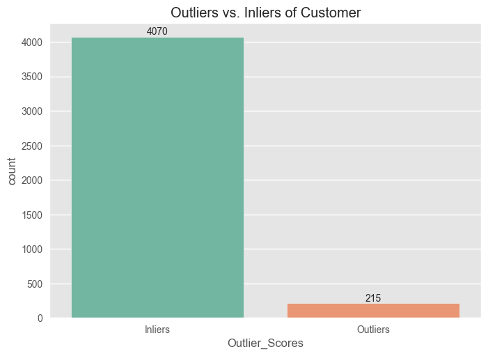

```python
ax = sns.countplot(data = customer_data
              , x = customer_data['Outlier_Scores'].map({1: 'Inliers', -1: 'Outliers'})
              , palette = 'Set2'
              )

for i in ax.containers:
    ax.bar_label(i,)

plt.title('Outliers vs. Inliers of Customer')
plt.show()
```

**Strategy:**

- In this project, outliers contain about ~5% of the data. So `IsolationForest` works well.
- Split outliers into another dataframe, use them later if needed.
- Continue further analysis for the inliers.
- Drop 2 columns: *Outlier_Scores* and *Is_Outliers*

```python
customer_data_ouliers = customer_data[customer_data['Is_Outliers'] == 1]
customer_data_cleaned = customer_data[customer_data['Is_Outliers'] == 0]

customer_data_ouliers.drop(columns=[ 'Is_Outliers','Outlier_Scores'], inplace=True)
customer_data_cleaned.drop(columns=[ 'Is_Outliers','Outlier_Scores'], inplace=True)
```

```python
customer_data_cleaned.head()
```

|  | CustomerID | Days_Since_Last_Purchase | Total_Transactions | Total_Products_Purchased | Total_Spend | Average_Transaction_Value | Average_Days_Between_Purchases | Day_Of_Week | Hour | Unique_Products_Purchased | Is_UK | Cancellation_Frequency | Cancel_Rate | Monthly_Average_Spend | Monthly_Std_Spend | Trending_Slope |
| --- | --- | --- | --- | --- | --- | --- | --- | --- | --- | --- | --- | --- | --- | --- | --- | --- |
| 0 | 12346 | 325 | 2 | 0 | 0.00 | 0.000000 | 0.000000 | 1 | 10 | 1 | 1 | 1.0 | 0.5 | 0.000000 | 0.000000 | 0.000000 |
| 1 | 12347 | 2 | 7 | 2458 | 4310.00 | 615.714286 | 2.016575 | 1 | 14 | 103 | 0 | 0.0 | 0.0 | 615.714286 | 341.070789 | 38.876738 |
| 2 | 12348 | 75 | 4 | 2332 | 1437.24 | 359.310000 | 10.884615 | 3 | 19 | 21 | 0 | 0.0 | 0.0 | 359.310000 | 203.875689 | -270.587755 |
| 3 | 12349 | 18 | 1 | 630 | 1457.55 | 1457.550000 | 0.000000 | 0 | 9 | 72 | 0 | 0.0 | 0.0 | 1457.550000 | 0.000000 | 0.000000 |
| 4 | 12350 | 310 | 1 | 196 | 294.40 | 294.400000 | 0.000000 | 2 | 16 | 16 | 0 | 0.0 | 0.0 | 294.400000 | 0.000000 | 0.000000 |

Let's see how many customers left ^^

```python
print('Remaining customers:' , customer_data_cleaned.shape[0])
```

```
Remaining customers: 4070
```

## 3.6. Correlation Analysis

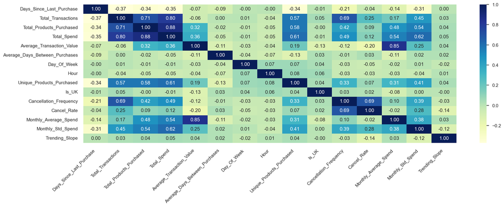

```python
sns.set_style("whitegrid")
sns.set_context("notebook")


plt.figure(figsize = (20,6))
sns.heatmap(data = customer_data_cleaned.corr(numeric_only=True), annot = True, cmap = "YlGnBu", fmt = '.2f')

plt.xticks(rotation = 45
           , ha = 'right')

plt.show()
```

There are some pairs of features that have high correlations:

- Monthly_Average_Spend and Average_Transaction_Value
- Total_Spend and Uniqe_Products_Purchased
- ... and so on

These variables move closely together, implying a possibility of **Multicollinearity**.

## 3.7. Feature Scailing

```python
from sklearn.preprocessing import StandardScaler
```

```python
customer_data_cleaned.columns
```

```
Index(['CustomerID', 'Days_Since_Last_Purchase', 'Total_Transactions',
       'Total_Products_Purchased', 'Total_Spend', 'Average_Transaction_Value',
       'Average_Days_Between_Purchases', 'Day_Of_Week', 'Hour',
       'Unique_Products_Purchased', 'Is_UK', 'Cancellation_Frequency',
       'Cancel_Rate', 'Monthly_Average_Spend', 'Monthly_Std_Spend',
       'Trending_Slope'],
      dtype='object')
```

```python
pre_scaled_columns = [ 'Days_Since_Last_Purchase', 'Total_Transactions',
       'Total_Products_Purchased', 'Total_Spend', 'Average_Transaction_Value',
       'Average_Days_Between_Purchases', 'Hour',
       'Unique_Products_Purchased', 'Cancellation_Frequency',
       'Cancel_Rate', 'Monthly_Average_Spend', 'Monthly_Std_Spend',
       'Trending_Slope']
```

```python
scaler = StandardScaler()
scaler
```

```
StandardScaler()
```

```python
customer_data_scaled = customer_data_cleaned.copy()

customer_data_scaled[pre_scaled_columns] = scaler.fit_transform(customer_data_scaled[pre_scaled_columns])
customer_data_scaled
```

|  | CustomerID | Days_Since_Last_Purchase | Total_Transactions | Total_Products_Purchased | Total_Spend | Average_Transaction_Value | Average_Days_Between_Purchases | Day_Of_Week | Hour | Unique_Products_Purchased | Is_UK | Cancellation_Frequency | Cancel_Rate | Monthly_Average_Spend | Monthly_Std_Spend | Trending_Slope |
| --- | --- | --- | --- | --- | --- | --- | --- | --- | --- | --- | --- | --- | --- | --- | --- | --- |
| 0 | 12346 | 2.364696 | -0.477864 | -0.769735 | -0.824326 | -1.305773 | -0.314646 | 1 | -1.088514 | -0.905770 | 1 | 0.360658 | 2.381605 | -1.270733 | -0.717355 | 0.100764 |
| 1 | 12347 | -0.901766 | 0.662978 | 2.021179 | 2.351817 | 1.499599 | -0.124572 | 1 | 0.646798 | 0.790878 | 0 | -0.524673 | -0.593469 | 0.925523 | 1.277640 | 0.128259 |
| 2 | 12348 | -0.163526 | -0.021527 | 1.878113 | 0.234811 | 0.331347 | 0.711294 | 3 | 2.815938 | -0.573094 | 0 | -0.524673 | -0.593469 | 0.010927 | 0.475157 | -0.090600 |
| 3 | 12349 | -0.739960 | -0.706033 | -0.054407 | 0.249778 | 5.335245 | -0.314646 | 0 | -1.522342 | 0.275230 | 0 | -0.524673 | -0.593469 | 3.928354 | -0.717355 | 0.100764 |
| 4 | 12350 | 2.213003 | -0.706033 | -0.547189 | -0.607376 | 0.035598 | -0.314646 | 2 | 1.514454 | -0.656263 | 0 | -0.524673 | -0.593469 | -0.220607 | -0.717355 | 0.100764 |
| ... | ... | ... | ... | ... | ... | ... | ... | ... | ... | ... | ... | ... | ... | ... | ... | ... |
| 4280 | 18280 | 1.879277 | -0.706033 | -0.718640 | -0.691238 | -0.482907 | -0.314646 | 0 | -1.522342 | -0.756066 | 1 | -0.524673 | -0.593469 | -0.626532 | -0.717355 | 0.100764 |
| 4281 | 18281 | 0.898327 | -0.706033 | -0.708421 | -0.764768 | -0.937533 | -0.314646 | 6 | -1.088514 | -0.805967 | 1 | -0.524673 | -0.593469 | -0.982448 | -0.717355 | 0.100764 |
| 4282 | 18282 | -0.851202 | -0.249696 | -0.658462 | -0.694185 | -1.037559 | 0.620059 | 4 | 0.212970 | -0.722798 | 1 | 0.360658 | 1.389914 | -0.955766 | -0.630830 | 0.056380 |
| 4283 | 18283 | -0.891653 | 2.716494 | 0.768787 | 0.678690 | -0.724966 | -0.270800 | 3 | 0.646798 | 3.435654 | 1 | -0.524673 | -0.593469 | -0.543214 | 0.252436 | 0.247065 |
| 4284 | 18287 | -0.497251 | -0.249696 | 1.031074 | 0.529610 | 1.484619 | -0.097447 | 2 | -1.088514 | 0.058991 | 1 | -0.524673 | -0.593469 | 2.006060 | 0.551244 | 0.621366 |

4070 rows × 16 columns

## 3.8. Dimensional Reduction

**Why:**

- Multicollinearity detected in previous step
- Better Clustering with K-means since K-means is a distance based algorithm then too much features can cause the less informative of the dataset. Less features may help K-means to cluster better.
- Noise Reduction by focusing on some importance features
- Enhance visualizations
- Imporve computing speed

**Which:**

In this step, we are considering the application of dimensionality reduction techniques to simplify our data while retaining the essential information. Among various methods such as `KernelPCA`, `ICA`, `ISOMAP`, `TSNE`, and `UMAP`, I am starting with `PCA (Principal Component Analysis)` for the following reasons:

- Good Starting Point: PCA is effective at capturing linear relationships in the data, which is important given the multicollinearity we found. It helps reduce the number of features while retaining most of the important information, making our clustering analysis potentially more accurate and easier to interpret.
- Computational Efficiency: PCA is computationally efficient, so it won’t significantly increase processing time.

However, we’re keeping our options open. If PCA doesn’t capture enough variance, meaning it might miss out on important information, we might explore other non-linear methods. These methods could provide a more detailed view of complex patterns in the data, but they may require more computation and time.

```python
from sklearn.decomposition import PCA
```

```python
# Setting CustomerID as the index column
customer_data_scaled.set_index('CustomerID', inplace=True)

# Apply PCA
pca = PCA().fit(customer_data_scaled)
pca
```

```
PCA()
```

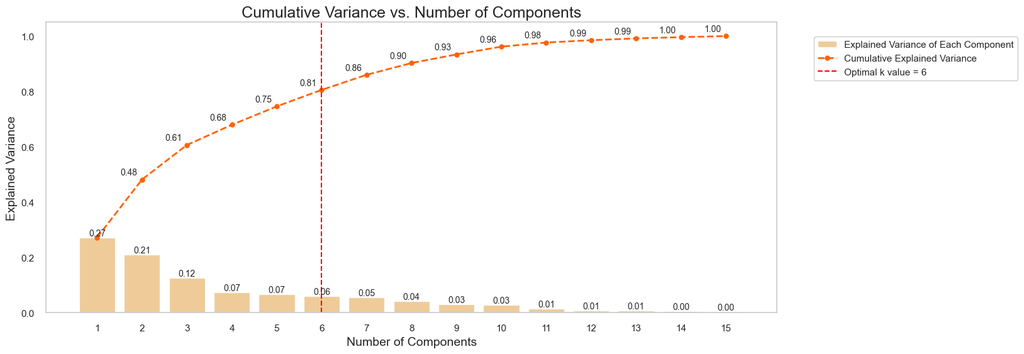

```python
explained_variance_ratio = pca.explained_variance_ratio_
cumulative_explained_variance = np.cumsum(explained_variance_ratio)

optimal_k = 6

plt.figure(figsize=(15, 6))

# Bar chart for the explained variance of each component
barplot = sns.barplot(x=list(range(1, len(cumulative_explained_variance) + 1)),
                      y=explained_variance_ratio,
                      color='#fcc36d',
                      alpha=0.8)

# Line plot for the cumulative explained variance
lineplot, = plt.plot(range(0, len(cumulative_explained_variance)), cumulative_explained_variance,
                     marker='o', linestyle='--', color='#ff6200', linewidth=2)

# Plot optimal k value line
optimal_k_line = plt.axvline(optimal_k - 1, color='red', linestyle='--', label=f'Optimal k value = {optimal_k}')

# Set labels and title
plt.xlabel('Number of Components', fontsize=14)
plt.ylabel('Explained Variance', fontsize=14)
plt.title('Cumulative Variance vs. Number of Components', fontsize=18)

# Customize ticks and legend
plt.xticks(range(0, len(cumulative_explained_variance)))
plt.legend(handles=[barplot.patches[0], lineplot, optimal_k_line],
           labels=['Explained Variance of Each Component', 'Cumulative Explained Variance', f'Optimal k value = {optimal_k}'],
           loc=(0.62, 0.1),
           bbox_to_anchor=(1.05, 0.8),
           frameon=True,
           framealpha=1.0)

# Display the variance values for both graphs on the plots
x_offset = -0.3
y_offset = 0.01
for i, (ev_ratio, cum_ev_ratio) in enumerate(zip(explained_variance_ratio, cumulative_explained_variance)):
    plt.text(i, ev_ratio, f"{ev_ratio:.2f}", ha="center", va="bottom", fontsize=10)
    if i > 0:
        plt.text(i + x_offset, cum_ev_ratio + y_offset, f"{cum_ev_ratio:.2f}", ha="center", va="bottom", fontsize=10)

plt.grid(False)
plt.show()
```

To determine the optimal number of components, we typically look for the "elbow point" on the plot.

From the plot, it appears that the rate of increase in cumulative variance begins to taper off **after the 6th component, which accounts for approximately 81%** of the total variance.

In the context of customer segmentation, it's important to keep enough information to accurately identify distinct customer groups. Therefore, retaining the first 6 components seems like a reasonable choice. They collectively capture a significant portion of the variance while reducing the dataset's dimensionality.

```python
# Creating a PCA object with 6 components
pca = PCA(n_components=6, random_state = 42)

# Fitting and transforming the original data to the new PCA dataframe
customer_data_pca = pca.fit_transform(customer_data_scaled)

# Creating a new dataframe from the PCA dataframe, with columns labeled PC1, PC2, etc.
customer_data_pca = pd.DataFrame(customer_data_pca, columns=['PC'+str(i+1) for i in range(pca.n_components_)])

# Adding the CustomerID index back to the new PCA dataframe
customer_data_pca.index = customer_data_scaled.index
```

```python
customer_data_pca
```

| CustomerID | PC1 | PC2 | PC3 | PC4 | PC5 | PC6 |
| --- | --- | --- | --- | --- | --- | --- |
| 12346 | -2.008651 | -1.737604 | -2.367384 | -1.703024 | -0.287408 | 1.976157 |
| 12347 | 3.293514 | -1.443549 | 1.928351 | 0.752986 | -0.169012 | -0.786635 |
| 12348 | 0.611355 | 0.568745 | 0.722391 | 0.919500 | -0.815395 | -1.737688 |
| 12349 | 1.628160 | -2.730849 | 5.585956 | -1.941364 | 1.089819 | 0.704577 |
| 12350 | -2.026492 | -0.502494 | 0.667558 | -0.277420 | -1.495086 | 0.216499 |
| ... | ... | ... | ... | ... | ... | ... |
| 18280 | -2.203774 | -2.647653 | 0.135626 | -0.408042 | 0.249111 | 1.369353 |
| 18281 | -2.287979 | 3.364751 | -0.395960 | -0.067892 | 0.561250 | 0.998503 |
| 18282 | -1.110251 | 1.357503 | -1.971440 | -0.022772 | 0.449942 | -0.210959 |
| 18283 | 2.576528 | 0.772925 | -0.640374 | 2.581534 | -1.157880 | -0.769577 |
| 18287 | 1.463886 | -0.628566 | 2.463847 | -0.220318 | 0.950722 | 0.620463 |

4070 rows × 6 columns

```python
# Define a function to highlight the top 3 absolute values in each column of a dataframe
def highlight_top3(column):
    top3 = column.abs().nlargest(3).index
    return ['background-color:  darkgreen' if i in top3 else '' for i in column.index]

# Create the PCA component DataFrame and apply the highlighting function
pc_df = pd.DataFrame(pca.components_.T, columns=['PC{}'.format(i+1) for i in range(pca.n_components_)],
                     index=customer_data_scaled.columns)

pc_df.style.apply(highlight_top3, axis=0)
```

|  | PC1 | PC2 | PC3 | PC4 | PC5 | PC6 |
| --- | --- | --- | --- | --- | --- | --- |
| Days_Since_Last_Purchase | -0.221049 | -0.009334 | 0.049851 | -0.319647 | -0.193325 | 0.417757 |
| Total_Transactions | 0.387273 | 0.011258 | -0.236155 | 0.205270 | -0.033873 | 0.076605 |
| Total_Products_Purchased | 0.412052 | -0.000058 | 0.070321 | 0.126818 | 0.030131 | 0.032508 |
| Total_Spend | 0.440168 | 0.004655 | 0.067332 | 0.086599 | 0.015723 | 0.054097 |
| Average_Transaction_Value | 0.170688 | -0.019587 | 0.571220 | -0.252436 | 0.065162 | 0.027196 |
| Average_Days_Between_Purchases | -0.024721 | -0.037041 | -0.127882 | 0.181771 | 0.711480 | -0.233762 |
| Day_Of_Week | -0.012281 | 0.994802 | -0.009097 | -0.041270 | 0.069702 | 0.046267 |
| Hour | -0.020824 | 0.057162 | 0.002894 | 0.174766 | -0.612335 | -0.472961 |
| Unique_Products_Purchased | 0.334294 | 0.056073 | 0.023221 | 0.215679 | -0.214521 | -0.091850 |
| Is_UK | -0.000066 | 0.006326 | -0.021146 | 0.017094 | -0.009844 | -0.011291 |
| Cancellation_Frequency | 0.300131 | -0.018734 | -0.411575 | -0.190264 | -0.079350 | 0.200952 |
| Cancel_Rate | 0.138938 | -0.035332 | -0.442915 | -0.467287 | -0.042006 | 0.142832 |
| Monthly_Average_Spend | 0.269412 | -0.010873 | 0.461547 | -0.279460 | 0.028936 | 0.061940 |
| Monthly_Std_Spend | 0.337002 | 0.006327 | -0.012208 | -0.195160 | 0.116529 | -0.183408 |
| Trending_Slope | 0.002199 | -0.012943 | 0.098996 | 0.534365 | -0.038312 | 0.653903 |

# 4. K-Means Clustering

```python
from yellowbrick.cluster import KElbowVisualizer, SilhouetteVisualizer
from sklearn.cluster import KMeans
import matplotlib.gridspec as gridspec
```

## 4.1. Elbow method

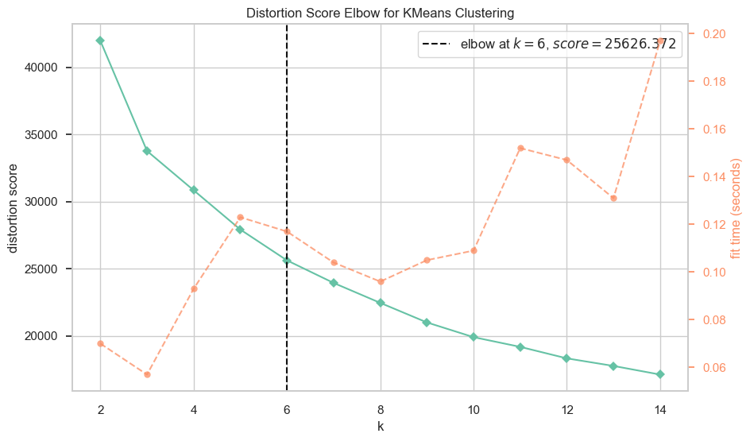

```python
# Set palette
sns.set_palette("Set2")

# Instantiate the clustering model with the specified parameters
km = KMeans(init='k-means++', n_init=10, max_iter=100, random_state=42)

# Create a figure and axis with the desired size
fig, ax = plt.subplots(figsize=(10, 6))

# Instantiate the KElbowVisualizer with the model and range of k values, and disable the timing plot
visualizer = KElbowVisualizer(km, k=(2, 15), ax=ax)

# Fit the data to the visualizer
visualizer.fit(customer_data_pca)

# Finalize and render the figure
visualizer.show()
```

## 4.2. Silhouette calculation

```python
from sklearn.metrics import silhouette_score, calinski_harabasz_score, davies_bouldin_score
```

```python
def silhouette_analysis(df, start_k, stop_k, figsize=(15, 16)):
    """
    Perform Silhouette analysis for a range of k values and visualize the results.
    """

    # Set the size of the figure
    plt.figure(figsize=figsize)

    # Create a grid with (stop_k - start_k + 1) rows and 2 columns
    grid = gridspec.GridSpec(stop_k - start_k + 1, 2)

    # Assign the first plot to the first row and both columns
    first_plot = plt.subplot(grid[0, :])

    # First plot: Silhouette scores for different k values
    sns.set_palette(['darkgreen'])

    silhouette_scores = []

    # Iterate through the range of k values
    for k in range(start_k, stop_k + 1):
        km = KMeans(n_clusters=k, init='k-means++', n_init=10, max_iter=100, random_state=0)
        km.fit(df)
        labels = km.predict(df)
        score = silhouette_score(df, labels)
        silhouette_scores.append(score)

    best_k = start_k + silhouette_scores.index(max(silhouette_scores))

    plt.plot(range(start_k, stop_k + 1), silhouette_scores, marker='o')
    plt.xticks(range(start_k, stop_k + 1))
    plt.xlabel('Number of clusters (k)')
    plt.ylabel('Silhouette score')
    plt.title('Average Silhouette Score for Different k Values', fontsize=15)

    # Add the optimal k value text to the plot
    optimal_k_text = f'The k value with the highest Silhouette score is: {best_k}'
    plt.text(10, 0.23, optimal_k_text, fontsize=12, verticalalignment='bottom',
             horizontalalignment='left', bbox=dict(facecolor='#fcc36d', edgecolor='#ff6200', boxstyle='round, pad=0.5'))


    # Second plot (subplot): Silhouette plots for each k value
    colors = sns.color_palette("bright")

    for i in range(start_k, stop_k + 1):
        km = KMeans(n_clusters=i, init='k-means++', n_init=10, max_iter=100, random_state=42)
        row_idx, col_idx = divmod(i - start_k, 2)

        # Assign the plots to the second, third, and fourth rows
        ax = plt.subplot(grid[row_idx + 1, col_idx])

        visualizer = SilhouetteVisualizer(km, colors=colors, ax=ax)
        visualizer.fit(df)

        # Add the Silhouette score text to the plot
        score = silhouette_score(df, km.labels_)
        ax.text(0.97, 0.02, f'Silhouette Score: {score:.4f}', fontsize=12, \
                ha='right', transform=ax.transAxes, color='red')

        ax.set_title(f'Silhouette Plot for {i} Clusters', fontsize=15)

        ax.grid(False)
    plt.tight_layout()
    plt.show()
```

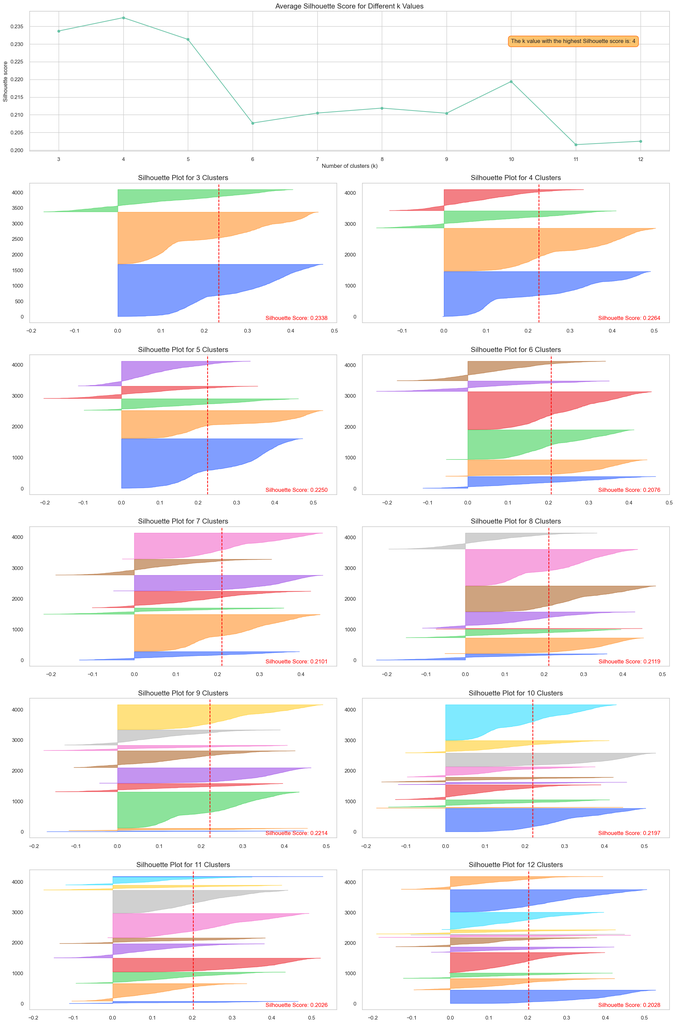

```python
silhouette_analysis(customer_data_pca, 3, 12, figsize=(20, 50))
```

##### Guidelines to Interpret Silhouette Plots and Determine the Optimal ( k ):

To interpret silhouette plots and identify the optimal number of clusters (( k )), consider the following criteria:

### 1️⃣ Analyze the Silhouette Plots:

- **Silhouette Score Width:**
  - **Wide Widths (closer to +1):** Indicate that the data points in the cluster are well separated from points in other clusters, suggesting well-defined clusters.
  - **Narrow Widths (closer to -1):** Show that data points in the cluster are not distinctly separated from other clusters, indicating poorly defined clusters.
- **Average Silhouette Score:**
  - **High Average Width:** A cluster with a high average silhouette score indicates well-separated clusters.
  - **Low Average Width:** A cluster with a low average silhouette score indicates poor separation between clusters.

### 2️⃣ Uniformity in Cluster Size:

- **Cluster Thickness:**
  - **Uniform Thickness:** Indicates that clusters have a roughly equal number of data points, suggesting a balanced clustering structure.
  - **Variable Thickness:** Signifies an imbalance in the data point distribution across clusters, with some clusters having many data points and others too few.

### 3️⃣ Peaks in Average Silhouette Score:

- **Clear Peaks:** A clear peak in the average silhouette score plot for a specific ( k ) value indicates this ( k ) might be optimal.

### 4️⃣ Minimize Fluctuations in Silhouette Plot Widths:

- **Uniform Widths:** Seek silhouette plots with similar widths across clusters, suggesting a more balanced and optimal clustering.
- **Variable Widths:** Avoid wide fluctuations in silhouette plot widths, indicating that clusters are not well-defined and may vary in compactness.

### 5️⃣ Optimal Cluster Selection:

- **Maximize the Overall Average Silhouette Score:** Choose the ( k ) value that gives the highest average silhouette score across all clusters, indicating well-defined clusters.
- **Avoid Below-Average Silhouette Scores:** Ensure most clusters have above-average silhouette scores to prevent suboptimal clustering structures.

### 6️⃣ Visual Inspection of Silhouette Plots:

- **Consistent Cluster Formation:** Visually inspect the silhouette plots for each ( k ) value to evaluate the consistency and structure of the formed clusters.
- **Cluster Compactness:** Look for more compact clusters, with data points having silhouette scores closer to +1, indicating better clustering.

**Optimal k Value: Silhouette Method Insights**

Based on above guidelines and after carefully considering the silhouette plots, it's clear that choosing ( k = 3 ) is the better option. This choice gives us clusters that are more evenly matched and well-defined, making our clustering solution stronger and more reliable.

```python
from collections import Counter
```

```python
# Apply KMeans clustering using the optimal k
kmeans = KMeans(n_clusters=3, init='k-means++', n_init=10, max_iter=100, random_state=42)
kmeans.fit(customer_data_pca)

# Get the frequency of each cluster
cluster_frequencies = Counter(kmeans.labels_)

cluster_frequencies
```

```
Counter({0: 1681, 1: 1671, 2: 718})
```

```python
cluster_frequencies.most_common()
```

```
[(0, 1681), (1, 1671), (2, 718)]
```

```python
# Create a mapping from old labels to new labels based on frequency
label_mapping = {label: new_label for new_label, (label, _) in
                 enumerate(cluster_frequencies.most_common())}

# Reverse the mapping to assign labels as per your criteria
label_mapping = {v: k for k, v in {0: 0
                                   , 1: 1
                                   , 2: 2}.items()}

# Apply the mapping to get the new labels
new_labels = np.array([label_mapping[label] for label in kmeans.labels_])

# Append the new cluster labels back to the original dataset
customer_data_cleaned['cluster'] = new_labels

# Append the new cluster labels to the PCA version of the dataset
customer_data_pca['cluster'] = new_labels
```

```python
# Display the first few rows of the original dataframe
customer_data_cleaned.head()
```

|  | CustomerID | Days_Since_Last_Purchase | Total_Transactions | Total_Products_Purchased | Total_Spend | Average_Transaction_Value | Average_Days_Between_Purchases | Day_Of_Week | Hour | Unique_Products_Purchased | Is_UK | Cancellation_Frequency | Cancel_Rate | Monthly_Average_Spend | Monthly_Std_Spend | Trending_Slope | cluster |
| --- | --- | --- | --- | --- | --- | --- | --- | --- | --- | --- | --- | --- | --- | --- | --- | --- | --- |
| 0 | 12346 | 325 | 2 | 0 | 0.00 | 0.000000 | 0.000000 | 1 | 10 | 1 | 1 | 1.0 | 0.5 | 0.000000 | 0.000000 | 0.000000 | 0 |
| 1 | 12347 | 2 | 7 | 2458 | 4310.00 | 615.714286 | 2.016575 | 1 | 14 | 103 | 0 | 0.0 | 0.0 | 615.714286 | 341.070789 | 38.876738 | 2 |
| 2 | 12348 | 75 | 4 | 2332 | 1437.24 | 359.310000 | 10.884615 | 3 | 19 | 21 | 0 | 0.0 | 0.0 | 359.310000 | 203.875689 | -270.587755 | 1 |
| 3 | 12349 | 18 | 1 | 630 | 1457.55 | 1457.550000 | 0.000000 | 0 | 9 | 72 | 0 | 0.0 | 0.0 | 1457.550000 | 0.000000 | 0.000000 | 0 |
| 4 | 12350 | 310 | 1 | 196 | 294.40 | 294.400000 | 0.000000 | 2 | 16 | 16 | 0 | 0.0 | 0.0 | 294.400000 | 0.000000 | 0.000000 | 0 |

## 4.3. Model Evaluation

### 4.3.1. 3D ScatterPlot of PCA

```python
import plotly.graph_objects as go
```

```python
colors = ['#e8000b', '#1ac938', '#023eff']
```

```python
cluster_0 = customer_data_pca[customer_data_pca['cluster'] == 0]
cluster_1 = customer_data_pca[customer_data_pca['cluster'] == 1]
cluster_2 = customer_data_pca[customer_data_pca['cluster'] == 2]
```

```python
customer_data_pca
```

| CustomerID | PC1 | PC2 | PC3 | PC4 | PC5 | PC6 | cluster |
| --- | --- | --- | --- | --- | --- | --- | --- |
| 12346 | -2.008651 | -1.737604 | -2.367384 | -1.703024 | -0.287408 | 1.976157 | 0 |
| 12347 | 3.293514 | -1.443549 | 1.928351 | 0.752986 | -0.169012 | -0.786635 | 2 |
| 12348 | 0.611355 | 0.568745 | 0.722391 | 0.919500 | -0.815395 | -1.737688 | 1 |
| 12349 | 1.628160 | -2.730849 | 5.585956 | -1.941364 | 1.089819 | 0.704577 | 0 |
| 12350 | -2.026492 | -0.502494 | 0.667558 | -0.277420 | -1.495086 | 0.216499 | 0 |
| ... | ... | ... | ... | ... | ... | ... | ... |
| 18280 | -2.203774 | -2.647653 | 0.135626 | -0.408042 | 0.249111 | 1.369353 | 0 |
| 18281 | -2.287979 | 3.364751 | -0.395960 | -0.067892 | 0.561250 | 0.998503 | 1 |
| 18282 | -1.110251 | 1.357503 | -1.971440 | -0.022772 | 0.449942 | -0.210959 | 1 |
| 18283 | 2.576528 | 0.772925 | -0.640374 | 2.581534 | -1.157880 | -0.769577 | 2 |
| 18287 | 1.463886 | -0.628566 | 2.463847 | -0.220318 | 0.950722 | 0.620463 | 2 |

4070 rows × 7 columns

```python
fig = go.Figure()

fig.add_trace(go.Scatter3d(x=cluster_0['PC1'], y=cluster_0['PC2'], z=cluster_0['PC3'],
                           mode='markers', marker=dict(color=colors[0], size=5, opacity=0.4), name='Cluster 0'))
fig.add_trace(go.Scatter3d(x=cluster_1['PC1'], y=cluster_1['PC2'], z=cluster_1['PC3'],
                           mode='markers', marker=dict(color=colors[1], size=5, opacity=0.4), name='Cluster 1'))
fig.add_trace(go.Scatter3d(x=cluster_2['PC1'], y=cluster_2['PC2'], z=cluster_2['PC3'],
                           mode='markers', marker=dict(color=colors[2], size=5, opacity=0.4), name='Cluster 2'))

fig.update_layout(
    title=dict(text='3D Visualization of Customer Clusters in PCA Space', x=0.5),
    scene=dict(
        xaxis=dict(backgroundcolor="#fcf0dc", gridcolor='white', title='PC1'),
        yaxis=dict(backgroundcolor="#fcf0dc", gridcolor='white', title='PC2'),
        zaxis=dict(backgroundcolor="#fcf0dc", gridcolor='white', title='PC3'),
    ),
    width=900,
    height=800
)

fig.show()
```

### 4.3.2. Cluster Distribution

```python
cluster_percentage = (customer_data_pca['cluster'].value_counts(normalize=True) * 100).reset_index()
cluster_percentage.columns = ['Cluster', 'Percentage']
cluster_percentage.sort_values(by='Cluster', inplace=True)
cluster_percentage
```

|  | Cluster | Percentage |
| --- | --- | --- |
| 0 | 0 | 41.302211 |
| 1 | 1 | 41.056511 |
| 2 | 2 | 17.641278 |

```python
cluster_percentage['Cluster'] = cluster_percentage['Cluster'].astype('str')
```

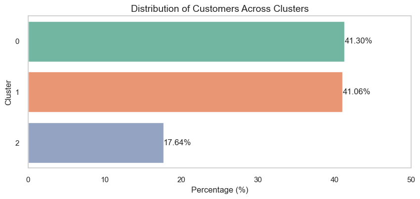

```python
# Create a horizontal bar plot
plt.figure(figsize=(10, 4))
ax = sns.barplot(data=cluster_percentage
            , y= 'Cluster'
            , x= 'Percentage'
            , palette='Set2')

for i in ax.containers:
    ax.bar_label(i, fmt = '%.2f%%')

plt.title('Distribution of Customers Across Clusters', fontsize=14)
plt.xlabel('Percentage (%)')
plt.xlim(0,50)

plt.grid(False)

plt.show()
```

### 4.3.3. Evaluation Metrics

##### Evaluating Clustering Effectiveness with Silhouette, Calinski-Harabasz, and Davies-Bouldin Scores

The metrics `silhouette_score`, `calinski_harabasz_score`, and `davies_bouldin_score` are commonly used measures to evaluate the effectiveness of clustering methods in machine learning. Below are the meanings of each metric:

###### 1. Silhouette Score

- **Meaning**: This metric measures how similar a data point is to other points in the same cluster compared to points in different clusters.
- **Value**:
  - The silhouette score ranges from -1 to 1.
  - A score closer to 1 indicates that the data points in that cluster are close to each other and far from points in other clusters, which means good clustering.
  - A score close to 0 indicates that the clusters have a high degree of overlap.
  - A negative score means that the data points are assigned to the wrong cluster.
- **Usage**: Used to evaluate the degree of separation between clusters. A well-isolated cluster will have a high silhouette score.

###### 2. Calinski-Harabasz Score (Variance Ratio Criterion)

- **Meaning**: This metric measures the ratio of the total variance between clusters to the total variance within clusters.
- **Value**:
  - A higher value means the clusters are more distinct.
  - A high Calinski-Harabasz score indicates that the clusters are well-separated and that data points within each cluster are close together.
- **Usage**: This is a good measure for clustering and the performance of clustering methods, especially when you want to find the optimal number of clusters.

###### 3. Davies-Bouldin Score

- **Meaning**: This metric measures the average similarity between each cluster and the nearest cluster, relative to the size of the cluster.
- **Value**:
  - A lower value indicates that the clustering is better, as the clusters are far apart and the data points within the same cluster are close together.
  - A higher value indicates that the clusters may overlap and the clustering is not good.
- **Usage**: Commonly used to determine the quality of clustering. This score is the inverse of the other scores, so a lower value is better.

##### In Summary:

- **Silhouette Score**: Evaluates the overall clustering of data points.
- **Calinski-Harabasz Score**: Measures the ratio of variance between clusters to variance within clusters, assessing the separation of clusters.
- **Davies-Bouldin Score**: Evaluates the similarity between clusters, with a lower value indicating better clustering.

```python
from tabulate import tabulate
from sklearn.metrics import silhouette_score, calinski_harabasz_score, davies_bouldin_score
```

```python
num_observations = len(customer_data_pca)

X = customer_data_pca.drop('cluster', axis=1)
clusters = customer_data_pca['cluster']

sil_score = silhouette_score(X, clusters)
calinski_score = calinski_harabasz_score(X, clusters)
davies_score = davies_bouldin_score(X, clusters)

table_data = [
    ["Number of Observations", num_observations],
    ["Silhouette Score", sil_score],
    ["Calinski Harabasz Score", calinski_score],
    ["Davies Bouldin Score", davies_score]
]

print(tabulate(table_data, headers=["Metric", "Value"], tablefmt='pretty'))
```

```
+-------------------------+---------------------+
|         Metric          |        Value        |
+-------------------------+---------------------+
| Number of Observations  |        4070         |
|    Silhouette Score     | 0.23378522469278054 |
| Calinski Harabasz Score | 1226.0713321635212  |
|  Davies Bouldin Score   |  1.393369017152799  |
+-------------------------+---------------------+
```

##### Analysis:

- **Silhouette Score: 0.23**

  The Silhouette Score of 0.23 is **close to 0**, indicating that the clusters have **significant overlap** and the clustering **is not very distinct**.

  This may suggest that the data is challenging to cluster, or that the current number of clusters is not optimal.
- **Calinski-Harabasz Score: 1226.07**

  The Calinski-Harabasz Score of 1226.07 is relatively high, which indicates that the clusters are **well separated** and that the data points within each cluster are **relatively close to each other**.

  This suggests that the overall clustering is **reasonably good**.
- **Davies-Bouldin Score: 1.39**

  The Davies-Bouldin Score of 1.39 is relatively low, indicating that the clusters are **well separated** from each other.

  A lower value typically suggests that the clustering has succeeded in keeping the **clusters distinct from one another**.

##### Conclusion:

Although the Silhouette Score is not high, both the Calinski-Harabasz and Davies-Bouldin Scores indicate that the clustering has a reasonable degree of separation.

However, we may want to reconsider the number of clusters or the clustering method to achieve better separation, especially if the goal is to have more clearly defined clusters.

# 5. Cluster Profiling and Analyzing

## 5.1. Approach 1: Radar Chart

```python
import plotly.express as px
from plotly.subplots import make_subplots
```

```python
df_customer = customer_data_cleaned.set_index('CustomerID')
```

```python
scaler
```

```
StandardScaler()
```

```python
df_customer_standardized = scaler.fit_transform(df_customer.drop(columns=['cluster'], axis=1))
df_customer_standardized = pd.DataFrame(df_customer_standardized, columns=df_customer.columns[:-1], index=df_customer.index)
df_customer_standardized['cluster'] = df_customer['cluster']
df_customer_standardized.head()
```

| CustomerID | Days_Since_Last_Purchase | Total_Transactions | Total_Products_Purchased | Total_Spend | Average_Transaction_Value | Average_Days_Between_Purchases | Day_Of_Week | Hour | Unique_Products_Purchased | Is_UK | Cancellation_Frequency | Cancel_Rate | Monthly_Average_Spend | Monthly_Std_Spend | Trending_Slope | cluster |
| --- | --- | --- | --- | --- | --- | --- | --- | --- | --- | --- | --- | --- | --- | --- | --- | --- |
| 12346 | 2.364696 | -0.477864 | -0.769735 | -0.824326 | -1.305773 | -0.314646 | -0.839868 | -1.088514 | -0.905770 | 0.300945 | 0.360658 | 2.381605 | -1.270733 | -0.717355 | 0.100764 | 0 |
| 12347 | -0.901766 | 0.662978 | 2.021179 | 2.351817 | 1.499599 | -0.124572 | -0.839868 | 0.646798 | 0.790878 | -3.322863 | -0.524673 | -0.593469 | 0.925523 | 1.277640 | 0.128259 | 2 |
| 12348 | -0.163526 | -0.021527 | 1.878113 | 0.234811 | 0.331347 | 0.711294 | 0.239470 | 2.815938 | -0.573094 | -3.322863 | -0.524673 | -0.593469 | 0.010927 | 0.475157 | -0.090600 | 1 |
| 12349 | -0.739960 | -0.706033 | -0.054407 | 0.249778 | 5.335245 | -0.314646 | -1.379537 | -1.522342 | 0.275230 | -3.322863 | -0.524673 | -0.593469 | 3.928354 | -0.717355 | 0.100764 | 0 |
| 12350 | 2.213003 | -0.706033 | -0.547189 | -0.607376 | 0.035598 | -0.314646 | -0.300199 | 1.514454 | -0.656263 | -3.322863 | -0.524673 | -0.593469 | -0.220607 | -0.717355 | 0.100764 | 0 |

```python
cluster_centroids = df_customer_standardized.groupby('cluster').mean().reset_index()
cluster_centroids
```

|  | cluster | Days_Since_Last_Purchase | Total_Transactions | Total_Products_Purchased | Total_Spend | Average_Transaction_Value | Average_Days_Between_Purchases | Day_Of_Week | Hour | Unique_Products_Purchased | Is_UK | Cancellation_Frequency | Cancel_Rate | Monthly_Average_Spend | Monthly_Std_Spend | Trending_Slope |
| --- | --- | --- | --- | --- | --- | --- | --- | --- | --- | --- | --- | --- | --- | --- | --- | --- |
| 0 | 0 | 0.119876 | -0.306976 | -0.331183 | -0.353680 | -0.123891 | 0.083175 | -0.845968 | -0.074012 | -0.310337 | -0.005171 | -0.224471 | -0.062826 | -0.198154 | -0.276362 | 0.016416 |
| 1 | 1 | 0.149605 | -0.312234 | -0.333788 | -0.351408 | -0.120785 | -0.032361 | 0.874412 | 0.103410 | -0.228602 | 0.014684 | -0.270359 | -0.138009 | -0.197009 | -0.268415 | -0.040692 |
| 2 | 2 | -0.628831 | 1.445360 | 1.552199 | 1.645877 | 0.571159 | -0.119418 | -0.054417 | -0.067387 | 1.258594 | -0.022068 | 1.154743 | 0.468277 | 0.922422 | 1.271709 | 0.056267 |

```python
cluster_centroids_melted = cluster_centroids.melt(id_vars=['cluster'], var_name='Metric', value_name='Value')
cluster_centroids_melted.head(6)
```

|  | cluster | Metric | Value |
| --- | --- | --- | --- |
| 0 | 0 | Days_Since_Last_Purchase | 0.119876 |
| 1 | 1 | Days_Since_Last_Purchase | 0.149605 |
| 2 | 2 | Days_Since_Last_Purchase | -0.628831 |
| 3 | 0 | Total_Transactions | -0.306976 |
| 4 | 1 | Total_Transactions | -0.312234 |
| 5 | 2 | Total_Transactions | 1.445360 |

```python
colors = ['#636EFA', '#EF553B', '#00CC96']

# Create radar charts for each cluster
for i, cluster_id in enumerate(cluster_centroids['cluster'].unique()):
    df_cluster = cluster_centroids_melted[cluster_centroids_melted['cluster'] == cluster_id]

    fig = px.line_polar(df_cluster, r='Value', theta='Metric', line_close=True,
                        title=f'Radar Chart for Cluster {cluster_id}')

    fig.update_traces(fill='toself', line=dict(color=colors[i]))
    fig.update_layout(
        polar=dict(
            radialaxis=dict(visible=True,  tickfont=dict(size=8)),
            angularaxis=dict(tickfont=dict(size=10))
        ),
        height=400,
        width=800,
        margin=dict(l=20, r=20, b=20, t=40)  # Adjust margins
    )
    fig.show()
```

## 5.2. Histogram chart

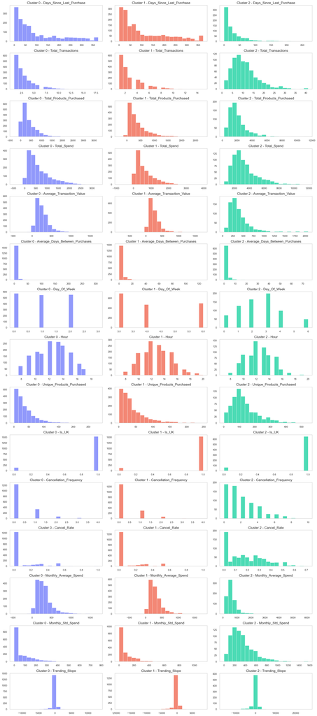

```python
features = customer_data_cleaned.columns[1:-1]
clusters = customer_data_cleaned['cluster'].unique()
clusters.sort()

n_rows = len(features)
n_cols = len(clusters)
fig, axes = plt.subplots(n_rows, n_cols, figsize=(20, 3*n_rows))

for i, feature in enumerate(features):
    for j, cluster in enumerate(clusters):
        data = customer_data_cleaned[customer_data_cleaned['cluster'] == cluster][feature]
        axes[i, j].hist(data, bins=20, color=colors[j], edgecolor='w', alpha=0.7)
        axes[i, j].set_title(f'Cluster {cluster} - {feature}', fontsize=15)
        axes[i, j].set_xlabel('')
        axes[i, j].set_ylabel('')
        axes[i, j].grid(False)

plt.tight_layout()

plt.show()
```

### 5.3. Customer Profiles:

`Cluster 1: The Small Weekend Shoppers`

`Cluster 2: The Grumpy Champions`